# Data Science Capstone Milestone Report

Keng Yew Hoe

10/19/2020

# INTRODUCTION

This project is to develop a predictive model for text starting with a realy large, unstructured database of the english language. This milestone report covers the tasks done up till week 2 which includes cleaning the data and doing exploratory data analysis.

# R LIBRARIES

Libraries used for this project.

```r
library(stringi) # stats files
library(NLP); library(openNLP)
library(tm) # Text mining
library(rJava)
library(RWeka) # tokenizer - create unigrams, bigrams, trigrams
library(RWekajars)
library(SnowballC) # Stemming
library(RColorBrewer) # Color palettes
library(qdap)
library(ggplot2) #visualization
setwd("d:/Desk/TextPredictor/final/en_US/")
```

## The data

From the dataset given, only english language data will be used for this project.

- en_US.blogs.txt
- en_US.news.txt
- en_US.twitter.txt.

The data was downloaded from Coursera to local machine and will be read from local disk.

```r
#Reading the data from my working directory
blogsText <- readLines(".//en_US.blogs.txt", encoding = "UTF-8", skipNul = T)
newsText <- file(".//en_US.news.txt" , open = "rb")
newsText <- readLines(newsText,encoding = "UTF-8", skipNul = T) #supposed to be 1010242 however only 77259 lines are read hence the different reading method
twitterText <- readLines("./en_US.twitter.txt", encoding = "UTF-8", skipNul = T)

#Getting some file data
file.info("./en_US.blogs.txt")$size / 1024^2
```

```
## [1] 200.4242
```

```r
file.info("./en_US.news.txt")$size  / 1024^2
```

```
## [1] 196.2775
```

```r
file.info("./en_US.twitter.txt")$size / 1024^2
```

```
## [1] 159.3641
```

```r
#Number of lines
length(blogsText)
```

```
## [1] 899288
```

```r
length(newsText)
```

```
## [1] 1010242
```

```r
length(twitterText)
```

```
## [1] 2360148
```

```r
#Number of words
sum(stri_count_words(blogsText))
```

```
## [1] 37546239
```

```r
sum(stri_count_words(newsText))
```

```
## [1] 34762395
```

```r
sum(stri_count_words(twitterText))
```

```
## [1] 30093413
```

```r
## The length of the longest line
max(nchar(blogsText))
```

```
## [1] 40833
```

```r
max(nchar(newsText))
```

```
## [1] 11384
```

```r
max(nchar(twitterText))
```

```
## [1] 140
```

## Creating a sub dataset

The data is big and will take a long time to load and be processed therefore subsets are created for test and application.

```r
set.seed(1234567)
subTwitter <- sample(twitterText, size = 10000, replace = TRUE)
subBlogs <- sample(blogsText, size = 10000, replace = TRUE)
subNews <- sample(newsText, size = 10000, replace = TRUE)
sampleTotal <- c(subTwitter, subBlogs, subNews)
length(sampleTotal)
writeLines(sampleTotal, "./sampleTotal.txt")
```

[output not shown]

Each file contributes 10,000 lines of text compile a new text file called sampleTotal.txt which has a total of 30,000 lines.

## Cleaning and exploring the data

Profanity Words data is from Luis von Ahn’s research group at CMU (http://www.cs.cmu.edu/~biglou/resources/). The library used here is TM that loads the corpus into memory and allow calls to the methods to clean the data.

```r
textCon <- file("./sampleTotal.txt")
textCorpus <- readLines(textCon)
textCorpus <- Corpus(VectorSource(textCorpus)) #reading the data as a list

#Cleaning the data with the tm package
textCorpus <- tm_map(textCorpus, content_transformer(function(x) iconv(x, "UTF-8", sub="byte")))
textCorpus <- tm_map(textCorpus, content_transformer(tolower))
textCorpus <- tm_map(textCorpus, content_transformer(removePunctuation), preserve_intra_word_dashes=TRUE)

#Removing profanity
profanity = readLines("./badWords.txt")
textCorpus <- tm_map(textCorpus, removeWords, profanity)
#Removing numbers
textCorpus <- tm_map(textCorpus, content_transformer(removeNumbers))
#Removing URLs
removeURL <- function(x) gsub("http[[:alnum:]]*","", x)
textCorpus <- tm_map(textCorpus, content_transformer(removeURL))
#Removing stop wordsd (a, as , at , so, etc...)
textCorpus <- tm_map(textCorpus, removeWords, stopwords("english"))
#Convert corpus to plain text document
textCorpus <- tm_map(textCorpus, PlainTextDocument)
#save in individual text file
writeCorpus(textCorpus)
```

## Tokenization of the Data

Let’s read the text to break it into words and sentences, and to turn it into n-grams. These are all called tokenization because we are breaking up the text into units of meaning, called tokens.

In Natural Language Processing (NLP), *n*-gram is a contiguous sequence of n items from a given sequence of text or speech. Unigrams are single words. Bigrams are two words combinations. Trigrams are three-word combinations.

The tokenizer method is allowed in R using the package RWeka. The following function is used to extract 1-grams, 2-grams, 3-grams and 4-grams from the text Corpus using RWeka.

```r
#Defining the function
library(RWeka)
uniGramTokenizer <- function(x) NGramTokenizer(x, Weka_control(min = 1, max = 1,delimiters = " \\r\\n\\t.,;:\"()?!"))
biGramTokenizer <- function(x) NGramTokenizer(x, Weka_control(min = 2, max = 2,delimiters = " \\r\\n\\t.,;:\"()?!"))
triGramTokenizer <- function(x) NGramTokenizer(x, Weka_control(min = 3, max = 3,delimiters = " \\r\\n\\t.,;:\"()?!"))
quadGramTokenizer <- function(x) NGramTokenizer(x, Weka_control(min = 4, max = 4,delimiters = " \\r\\n\\t.,;:\"()?!"))
```

```r
## Tokenizer function to get unigram
unigram <- uniGramTokenizer(textCorpus)
unigram <- data.frame(table(unigram))
unigram <- unigram[order(unigram$Freq,decreasing = TRUE),]
names(unigram) <- c("word1", "freq")
head(unigram)
```

```
##       word1 freq
## 39552  said 2908
## 50629  will 2763
## 32182   one 2570
## 24363  just 2181
## 6870    can 2057
## 26431  like 2046
```

```r
unigram$word1 <- as.character(unigram$word1)
write.csv(unigram[unigram$freq > 1,],"unigram.csv",row.names=F)
unigram <- read.csv("unigram.csv",stringsAsFactors = F)
saveRDS(unigram, file = "unigram.RData")
```

** Plotting UNIGRAM

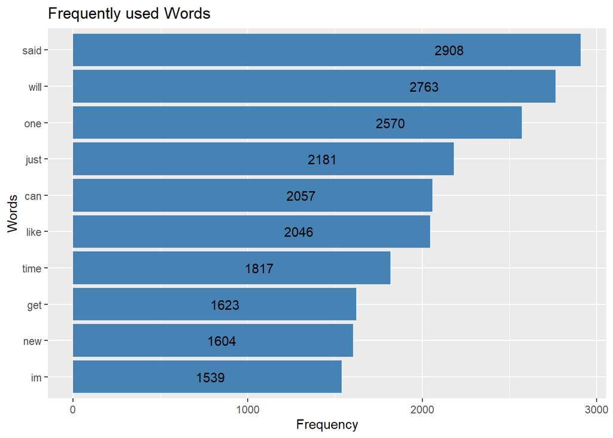

```r
## Unigram Plot
library(ggplot2)
unigram <- readRDS("unigram.RData")
unigramPlot <- ggplot(data=unigram[1:10,], aes(x = reorder(word1,freq), y = freq))+
  geom_bar(stat="identity", fill = "steelblue")  +
  ggtitle("Frequently used Words") +
  geom_text(data = unigram[1:10,], aes(x = word1, y = freq, label = freq), hjust=5, position = "identity") +
  labs(y="Frequency",x="Words") + coord_flip()
unigramPlot
```

### 7.2 - Obtaining the biGrams

```r
# Tokenizer function to get bigrams
bigram <- biGramTokenizer(textCorpus)
bigram <- data.frame(table(bigram))
bigram <- bigram[order(bigram$Freq,decreasing = TRUE),]
names(bigram) <- c("words","freq")
head(bigram)
```

```
##                 words freq
## 187104      last year  191
## 94949       dont know  176
## 231792       new york  163
## 291532      right now  136
## 398613      years ago  135
## 37329  board district  126
```

```r
bigram$words <- as.character(bigram$words)
```

** Plotting BIGRAM

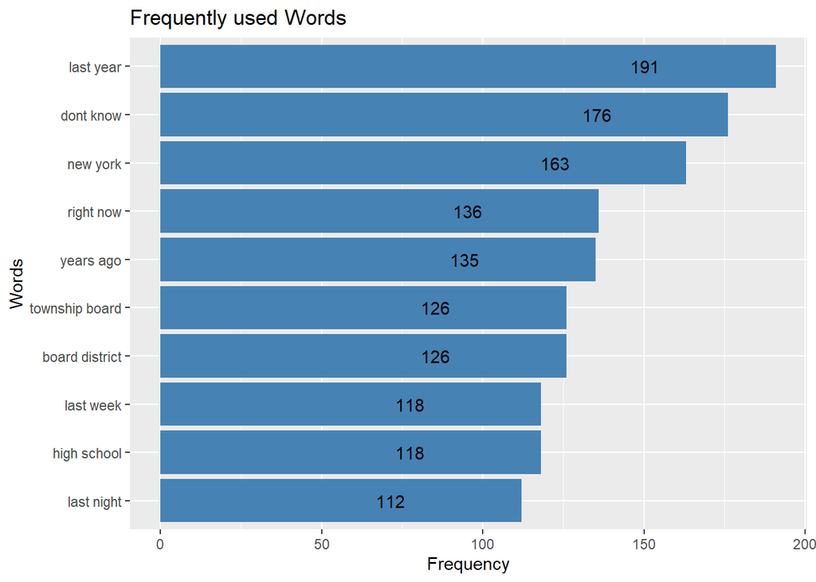

```r
bigramPlot <- ggplot(data=bigram[1:10,], aes(x = reorder(words,freq), y = freq))+
  geom_bar(stat="identity", fill = "steelblue")  +
  ggtitle("Frequently used Words") +
  geom_text(data = bigram[1:10,], aes(x = words, y = freq, label = freq), hjust=5, position = "identity") +
  labs(y="Frequency",x="Words") + coord_flip()
bigramPlot
```

```r
#Splitting the words into 2 strings
str2 <- strsplit(bigram$words,split=" ")
bigram <- transform(bigram,
                    one = sapply(str2,"[[",1),
                    two = sapply(str2,"[[",2))
bigram <- data.frame(word1 = bigram$one,word2 = bigram$two,freq = bigram$freq,stringsAsFactors=FALSE)
## saving files
write.csv(bigram[bigram$freq > 1,],"bigram.csv",row.names=F)
bigram <- read.csv("bigram.csv",stringsAsFactors = F)
saveRDS(bigram,"bigram.RData")
```

### 7.3 - Obtaining the triGrams

```r
# Tokenizer function to get trigrams
trigram <- triGramTokenizer(textCorpus)
trigram <- data.frame(table(trigram))
trigram <- trigram[order(trigram$Freq,decreasing = TRUE),]
names(trigram) <- c("words","freq")
head(trigram)
```

```
##                                words freq
## 418626       township board district  126
## 104141      district candidate filed   67
## 42006       board district candidate   59
## 382872 state representative district   30
## 269316                 new york city   24
## 56668                  cant wait see   19
```

** Plotting TRIGRAM

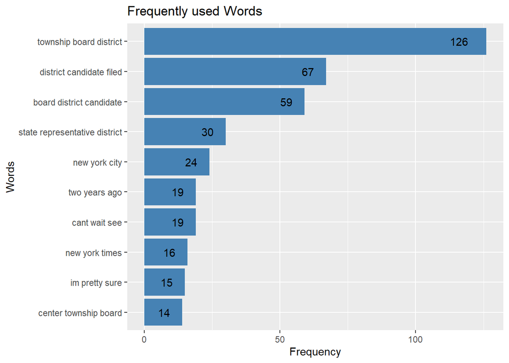

```r
trigramPlot <- ggplot(data=trigram[1:10,], aes(x = reorder(words,freq), y = freq))+
  geom_bar(stat="identity", fill = "steelblue")  +
  ggtitle("Frequently used Words") +
  geom_text(data = trigram[1:10,], aes(x = words, y = freq, label = freq), hjust=2, position = "identity") +
  labs(y="Frequency",x="Words") + coord_flip()
trigramPlot
```

```r
# Splitting the trigram words into individual words
trigram$words <- as.character(trigram$words)
str3 <- strsplit(trigram$words,split=" ")
trigram <- transform(trigram,
                     one = sapply(str3,"[[",1),
                     two = sapply(str3,"[[",2),
                     three = sapply(str3,"[[",3))
# trigram$words <- NULL
trigram <- data.frame(word1 = trigram$one,word2 = trigram$two,
                      word3 = trigram$three, freq = trigram$freq,stringsAsFactors=FALSE)
# saving files
write.csv(trigram[trigram$freq > 1,],"trigram.csv",row.names=F)
trigram <- read.csv("trigram.csv",stringsAsFactors = F)
saveRDS(trigram,"trigram.RData")
```

### 7.4 - Obtaining the quadGrams

```r
# Tokenizer function to get quadgrams
quadgram <- quadGramTokenizer(textCorpus)
quadgram <- data.frame(table(quadgram))
quadgram <- quadgram[order(quadgram$Freq,decreasing = TRUE),]
names(quadgram) <- c("words","freq")
quadgram$words <- as.character(quadgram$words)
head(quadgram)
```

```
##                                    words freq
## 42204     board district candidate filed   59
## 421935 township board district candidate   59
## 61527     center township board district   14
## 95638    decatur township board district   14
## 148239  franklin township board district   14
## 219078  lawrence township board district   14
```

** Plotting QUADGRAM

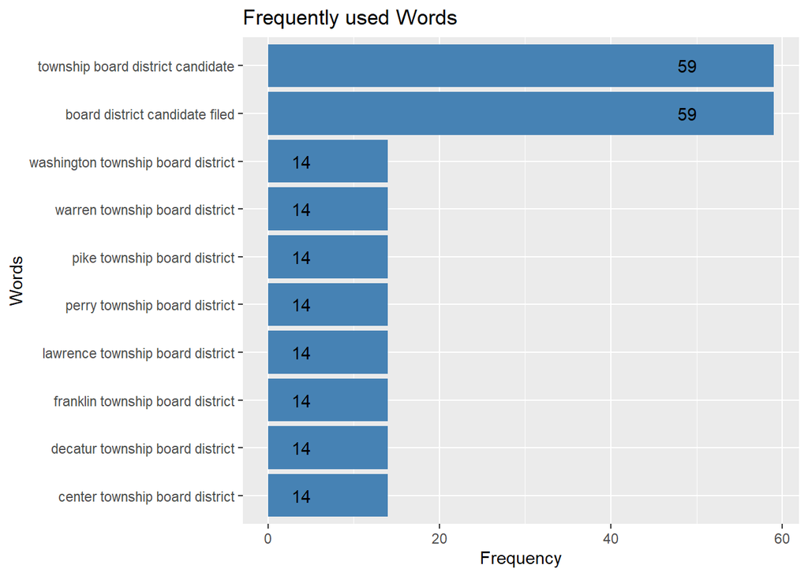

```r
quadgramPlot <- ggplot(data=quadgram[1:10,], aes(x = reorder(words,freq), y = freq))+
  geom_bar(stat="identity", fill = "steelblue")  +
  ggtitle("Frequently used Words") +
  geom_text(data = quadgram[1:10,], aes(x = words, y = freq, label = freq), hjust=5, position = "identity") +
  labs(y="Frequency",x="Words") + coord_flip()
quadgramPlot
```

```r
#splitting the quadgram into 4 words
str4 <- strsplit(quadgram$words,split=" ")
quadgram <- transform(quadgram,
                      one = sapply(str4,"[[",1),
                      two = sapply(str4,"[[",2),
                      three = sapply(str4,"[[",3),
                      four = sapply(str4,"[[",4))
# quadgram$words <- NULL
quadgram <- data.frame(word1 = quadgram$one,
                       word2 = quadgram$two,
                       word3 = quadgram$three,
                       word4 = quadgram$four,
                       freq = quadgram$freq, stringsAsFactors=FALSE)
# saving files
write.csv(quadgram[quadgram$freq > 1,],"quadgram.csv",row.names=F)
quadgram <- read.csv("quadgram.csv",stringsAsFactors = F)
saveRDS(quadgram,"quadgram.RData")
```

## Further considerations

- All the process from reading the file, cleaning and creating the n-grams is time-consuming for your computer.
- NLP uses intensive computer resource and is necessary a lot of tests get n-grams efficient keeping minimum files sizes.
- The techniques of removing words (cleaning) sometimes is not precise as we can suppose.
- Increasing the quality of n-gram tokenization could be critical to prediction accuracy at the prediction algorithm.

## Next Goal

- Build a Shiny app to allow the user input the word to obtain a suggestion of the next word.
- Develop the prediction algorithm implemented in Shiny app.
- Prepare a pitch about the app and publish it at “shinyapps.io” server.